# stat_T6

```python
import numpy as np
import scipy.stats as st
import matplotlib.pyplot as plt
import pandas as pd
```

## Goodness-of-fit test - The discrete case

```python
# copy-paste the data
s = '1 1 3 2 3 1 1 1 4 3 2 7 1 2 1 1 2 4 2 1 1 1 2 2 5 2 1 1 1 1 3 2 2 1 1 1 1 1 6 1 3 1 1 3 2 1 1 2 1 4' # s is a string
L = s.split(' ') # we cut s into a list of strings by using the space ' ' as a separator

L = list(map(int,L)) # we use map to transfor each string into an integer (for a real number use float instead of int)
                        # and we make a list of it

x= np.array(L) # we transorm this list into an array

n = len(x)
x, n
```

```
(array([1, 1, 3, 2, 3, 1, 1, 1, 4, 3, 2, 7, 1, 2, 1, 1, 2, 4, 2, 1, 1, 1,
        2, 2, 5, 2, 1, 1, 1, 1, 3, 2, 2, 1, 1, 1, 1, 1, 6, 1, 3, 1, 1, 3,
        2, 1, 1, 2, 1, 4]),
 50)
```

1. Comparison of plots

```python
values, ni = np.unique(x, return_counts = True)
values, ni
```

```
(array([1, 2, 3, 4, 5, 6, 7]), array([26, 12,  6,  3,  1,  1,  1]))
```

```python
pi = st.geom.pmf(values, p = 1/2)
pi
```

```
array([0.5      , 0.25     , 0.125    , 0.0625   , 0.03125  , 0.015625 ,
       0.0078125])
```

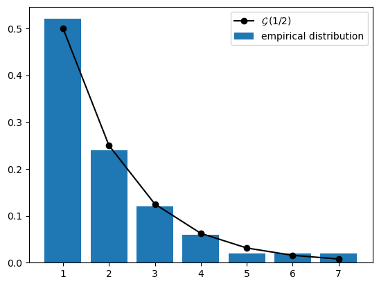

```python
plt.bar(values, ni/n, label = 'empirical distribution')
plt.plot(values, pi, '-ko', label = '$\mathcal{G}\,(1/2)$')
plt.legend()
plt.show()
```

2. Merging classes

```python
nj=np.hstack((ni[0:3],np.sum(ni[3:])))
nj
```

```
array([26, 12,  6,  6])
```

```python
npj=n*np.hstack((pi[0:3],1-np.sum(pi[0:3])))
npj
```

```
array([25.  , 12.5 ,  6.25,  6.25])
```

3. Computaion of $d^2$.

```python
dj2 = (nj-npj)**2/npj
dj2
```

```
array([0.04, 0.02, 0.01, 0.01])
```

```python
d2 = sum(dj2)
J = len(dj2)
d2,J
```

```
(0.07999999999999999, 4)
```

4. Chi-squared goodness-of-fit test

```python
alpha = 0.05
```

Under the hypothesis $H_0$, the variable $D2$ has a chi-sqared distribution with parameter $J-1$ and we reject the fit if the $p$-value is smaller than $\alpha=0.05$ of if d2 is larger than the critival value:

(a) Critical value:

```python
xc = st.chi2.ppf(1-alpha, df = J-1)
xc
```

```
7.814727903251179
```

Here of course d2 << xc because we used a real coin for the game (which means that the model is good!)

(b) p-value:

```python
p_value = st.chi2.sf(d2,J-1)
p_value
```

```
0.9941243682104942
```

Obviously the test confirm our impression that the data were distributed as a geometric distribution of parameter $1/2$ since p >> alpha

## Chi-squared test for comparing homogeneous samples

2. We do not need to make the table and only write the values:

```python
nkj = np.array([[13, 8, 12, 14], [98, 12, 29, 6], [8, 10, 6, 2], [124, 98, 149, 41]])
m, J = np.shape(nkj)
nkj, m, J
```

```
(array([[ 13,   8,  12,  14],
        [ 98,  12,  29,   6],
        [  8,  10,   6,   2],
        [124,  98, 149,  41]]),
 4,
 4)
```

3. We compute the average square distance of the samples to the average distribution:

We start by the margin:

```python
nk = np.sum(nkj, axis = 1)
nj = np.sum(nkj, axis = 0)
n = np.sum(nkj)
nj, nk, n
```

```
(array([243, 128, 196,  63]), array([ 47, 145,  26, 412]), 630)
```

Then we calculate the average distribution of samples:

```python
mkj = np.tensordot(nk,nj, axes = 0)/n
mkj
```

```
array([[ 18.12857143,   9.54920635,  14.62222222,   4.7       ],
       [ 55.92857143,  29.46031746,  45.11111111,  14.5       ],
       [ 10.02857143,   5.28253968,   8.08888889,   2.6       ],
       [158.91428571,  83.70793651, 128.17777778,  41.2       ]])
```

Finally, the distance is

```python
dkj = (nkj-mkj)**2/mkj
d2 = np.sum(dkj)
d2
```

```
92.10275748598384
```

4. Chi-squared test

```python
alpha = 0.05
```

(a) Critical value

```python
xc = st.chi2.ppf(1-alpha, (J-1)*(m-1))
xc
```

```
16.918977604620448
```

Our value is much larger than the critical value so we can say there is a significantly different demand on entrees according to the desert demand.

(b) p-value

```python
p = st.chi2.sf(d2,(J-1)*(m-1))
p
```

```
6.157084939472883e-16
```

Here p < < alpha therefore we can reject the similarity of samples and coclude as above.

## Goodness-of-fit test - The continuous case

We use the data `vols.txt`

```python
sr = pd.read_csv('vols.txt') # open the data file as a series (a 1D DataFrame)
sr
```

|  | vols |
| --- | --- |
| 0 | 1.909833 |
| 1 | 1.904669 |
| 2 | 1.915368 |
| 3 | 1.922803 |
| 4 | 1.905083 |
| ... | ... |
| 665 | 2.525850 |
| 666 | 2.527835 |
| 667 | 2.507825 |
| 668 | 2.528103 |
| 669 | 2.534740 |

670 rows × 1 columns

```python
x = np.array(sr.vols)
n = len(x)
x, n
```

```
(array([1.90983291, 1.90466853, 1.91536834, 1.92280288, 1.90508347,
        1.94976949, 1.91660464, 1.91486734, 1.90310226, 1.9149122 ,
        1.90231756, 1.92527141, 1.93807129, 1.9315535 , 1.90449458,
        1.90404312, 1.93886203, 1.94525674, 1.9266886 , 1.95545771,
        1.99129044, 1.96690489, 1.96469865, 1.98731567, 1.95051683,
        1.95242237, 1.98339581, 1.9801734 , 1.97630512, 1.98648547,
        1.98536267, 1.98906885, 1.96439885, 1.9846266 , 1.97783349,
        1.96982604, 1.95307953, 1.98900878, 2.01687919, 2.0303933 ,
        2.0370627 , 2.00524066, 2.00639442, 2.02747701, 2.02426147,
        2.04452378, 2.03994801, 2.03671705, 2.00256659, 2.00364426,
        2.00442637, 2.03991754, 2.04715041, 2.03418578, 2.00660415,
        2.03613623, 2.00551767, 2.00587464, 2.0320359 , 2.01644071,
        2.0326906 , 2.03745657, 2.02915929, 2.03700162, 2.01174135,
        2.03674788, 2.04852993, 2.04334651, 2.00431173, 2.01832183,
        2.01845994, 2.03425142, 2.02989708, 2.0394682 , 2.01838265,
        2.01030139, 2.00433333, 2.0885967 , 2.06028373, 2.06941358,
        2.07758893, 2.06144766, 2.08209703, 2.07422402, 2.05759228,
        2.0890966 , 2.05503032, 2.06470332, 2.06186865, 2.07654361,
        2.05457494, 2.07026577, 2.05524231, 2.0556142 , 2.08922139,
        2.06457852, 2.08017667, 2.09822113, 2.07162425, 2.08473761,
        2.08790496, 2.07163212, 2.0827749 , 2.05548775, 2.09668799,
        2.05937304, 2.06330894, 2.08989151, 2.07438019, 2.08844791,
        2.06980034, 2.06364694, 2.05186173, 2.08366475, 2.07147822,
        2.07258696, 2.08049286, 2.05297016, 2.06579057, 2.08863611,
        2.08482165, 2.05626661, 2.05650757, 2.05461762, 2.05039101,
        2.12115547, 2.13277866, 2.13614613, 2.12656046, 2.1054409 ,
        2.13158832, 2.10632499, 2.10671517, 2.1049297 , 2.10710136,
        2.10841256, 2.10981245, 2.11587399, 2.11582145, 2.11087817,
        2.11255209, 2.14464612, 2.13516116, 2.1277869 , 2.10922168,
        2.11060154, 2.10386734, 2.14569002, 2.13533576, 2.12788945,
        2.11567145, 2.10831018, 2.13112486, 2.14939674, 2.1085216 ,
        2.11288961, 2.11983997, 2.10369974, 2.1342048 , 2.12011942,
        2.14914176, 2.1201092 , 2.1310336 , 2.10771849, 2.11906726,
        2.1080567 , 2.13790562, 2.14355556, 2.11753884, 2.13427679,
        2.11470743, 2.12653147, 2.14162117, 2.12987451, 2.11676557,
        2.11496125, 2.12262963, 2.12113228, 2.11798032, 2.12791596,
        2.13712727, 2.12121674, 2.12146779, 2.10624364, 2.1012217 ,
        2.11450926, 2.11587603, 2.13268451, 2.1478468 , 2.14678654,
        2.12289432, 2.11202392, 2.1381949 , 2.13796637, 2.1370324 ,
        2.13718442, 2.10529602, 2.13407802, 2.12316303, 2.11060816,
```

[output cut: 80 more lines]

```
        2.38373882, 2.37192544, 2.37189101, 2.40585184, 2.44073408,
        2.41624277, 2.41231141, 2.41713566, 2.41878461, 2.42732769,
        2.42809601, 2.41979111, 2.41990654, 2.42576836, 2.43287653,
        2.44754576, 2.43611743, 2.42000399, 2.44159357, 2.40671692,
        2.40302334, 2.40421235, 2.40819492, 2.416211  , 2.41508634,
        2.40058405, 2.42699525, 2.40476863, 2.40732574, 2.43155706,
        2.44296602, 2.49871108, 2.47854192, 2.49984251, 2.47767708,
        2.47577292, 2.4665341 , 2.47150009, 2.47459031, 2.45355185,
        2.49438696, 2.45323168, 2.47180925, 2.49133148, 2.46972673,
        2.48067374, 2.49093204, 2.49431175, 2.49655558, 2.45953923,
        2.46292911, 2.49489328, 2.47966809, 2.475192  , 2.48064048,
        2.49097111, 2.47659446, 2.51010375, 2.52269467, 2.52139555,
        2.54830264, 2.53100275, 2.5347695 , 2.53600823, 2.51734476,
        2.52584952, 2.52783473, 2.50782476, 2.5281028 , 2.53474016]),
 670)
```

1. Histogram

```python
a = min(x)
b = max(x)
a,b
```

```
(1.90231756324491, 2.5483026374806)
```

Here is a short way to make the histogram: start by a `np.linspace`, plot with the `plt.hist` command which calculates the correct height when using the `density = True` parameter and adjust the bins until you ares satisfied.

At the same time, we fit the Gaussian standard deviation with the estimated parameters:

```python
m = np.mean(x)
s = np.std(x, ddof = 1)
m, s
```

```
(2.216366416606883, 0.1378802036693807)
```

```python
f = lambda t : st.norm.pdf(t, loc = m, scale = s) # PDF of the Gaussian target distribution
```

```python
t = np.linspace(1.9,2.6, 71) # discretization of the PDF plot
t
```

```
array([1.9 , 1.91, 1.92, 1.93, 1.94, 1.95, 1.96, 1.97, 1.98, 1.99, 2.  ,
       2.01, 2.02, 2.03, 2.04, 2.05, 2.06, 2.07, 2.08, 2.09, 2.1 , 2.11,
       2.12, 2.13, 2.14, 2.15, 2.16, 2.17, 2.18, 2.19, 2.2 , 2.21, 2.22,
       2.23, 2.24, 2.25, 2.26, 2.27, 2.28, 2.29, 2.3 , 2.31, 2.32, 2.33,
       2.34, 2.35, 2.36, 2.37, 2.38, 2.39, 2.4 , 2.41, 2.42, 2.43, 2.44,
       2.45, 2.46, 2.47, 2.48, 2.49, 2.5 , 2.51, 2.52, 2.53, 2.54, 2.55,
       2.56, 2.57, 2.58, 2.59, 2.6 ])
```

```python
bins = np.linspace(1.9,2.6, 15) # discretization for the classes
J = len(bins)-1
bins, J
```

```
(array([1.9 , 1.95, 2.  , 2.05, 2.1 , 2.15, 2.2 , 2.25, 2.3 , 2.35, 2.4 ,
        2.45, 2.5 , 2.55, 2.6 ]),
 14)
```

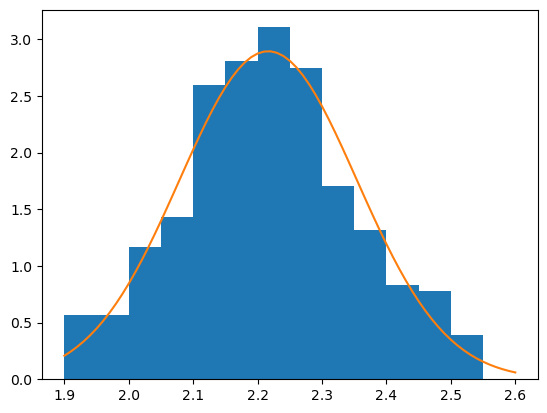

```python
plt.hist(x, bins = bins, density = True)[1]
plt.plot(t, f(t))
plt.show()
```

```python
nj = np.histogram(x, bins = bins)[0] # frequencies of classes
nj
```

```
array([ 19,  19,  39,  48,  87,  94, 104,  92,  57,  44,  28,  26,  13,
         0])
```

The last class being empty, we discard it.

```python
bins = bins[:-1]
nj = nj[:-1]
J = J-1
bins, nj, J
```

```
(array([1.9 , 1.95, 2.  , 2.05, 2.1 , 2.15, 2.2 , 2.25, 2.3 , 2.35, 2.4 ,
        2.45, 2.5 , 2.55]),
 array([ 19,  19,  39,  48,  87,  94, 104,  92,  57,  44,  28,  26,  13]),
 13)
```

Once we are satisfied, we can make the test. We start by computing the empirical distribution in the classes. The first class start at $-\infty$ and the last one ends at $+\infty$ (make a picture to understand).

```python
F = st.norm.cdf(bins[1:-1], loc = m, scale = s)
bins[1:-1], F
```

```
(array([1.95, 2.  , 2.05, 2.1 , 2.15, 2.2 , 2.25, 2.3 , 2.35, 2.4 , 2.45,
        2.5 ]),
 array([0.02668787, 0.05829662, 0.11379289, 0.19934377, 0.3151396 ,
        0.45275641, 0.59635879, 0.72793085, 0.83377746, 0.90854268,
        0.9549118 , 0.98016177]))
```

```python
F = np.hstack((0., F ,1.))
npj = n*np.diff(F)
bins, npj, np.sum(npj)
```

```
(array([1.9 , 1.95, 2.  , 2.05, 2.1 , 2.15, 2.2 , 2.25, 2.3 , 2.35, 2.4 ,
        2.45, 2.5 , 2.55]),
 array([17.88087413, 21.17785911, 37.18250027, 57.31909352, 77.58320663,
        92.20326346, 96.21359203, 88.15328143, 70.91722578, 50.09269694,
        31.06731249, 16.91748119, 13.29161302]),
 670.0)
```

We compute the distance between the emprical and the theoretical distributions d2.

```python
dj = (nj-npj)**2/npj
d2 = np.sum(dj)
d2
```

```
12.531593723552563
```

(a) With the critical region:

```python
alpha = 0.05
xc = st.chi2.ppf(1-alpha, J - 1 - 2) # ddof J-1-2 because we estimated 2 parameters
xc
```

```
18.307038053275146
```

We are below the threshold therefore we do not reject the ajustment and, unless we can use another test wich a different conclusion, we have no evidence of the distribution not being Gaussian.

(b) With the $p$-value:

```python
p = st.chi2.sf(d2,  J - 1 - 2)
p
```

```
0.2510520066812316
```

p >> alpha, we have the same conclusion (of course, it is the same test).